# Practical 2

## Question 8:

**Add rug marks to the density plot through geom_rug(). You can edit the colour and size of the rug marks using those arguments within the geom_rug() function.**

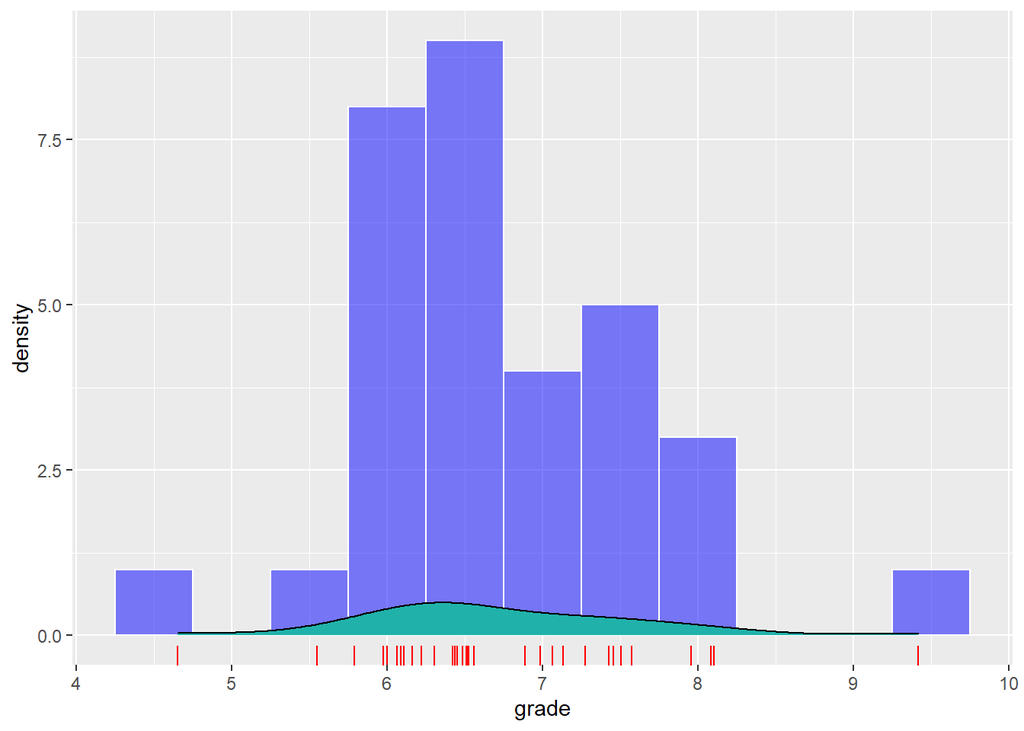

```r
gg_hist <- ggplot(data = gg_students, mapping = aes(x = grade)) +
  geom_histogram(binwidth = 0.5, fill="Blue", colour="White", alpha=0.5) +
  geom_density(fill = "light seagreen") +
  geom_rug(colour = "Red", size = 0.5)
gg_hist
```

## Question 9:

**Increase the data to ink ratio by removing the y axis label, setting the theme to theme_minimal(), and removing the border of the density polygon. Also set the limits of the x-axis to go from 0 to 10 using the xlim() function, because those are the plausible values for a student grade.**

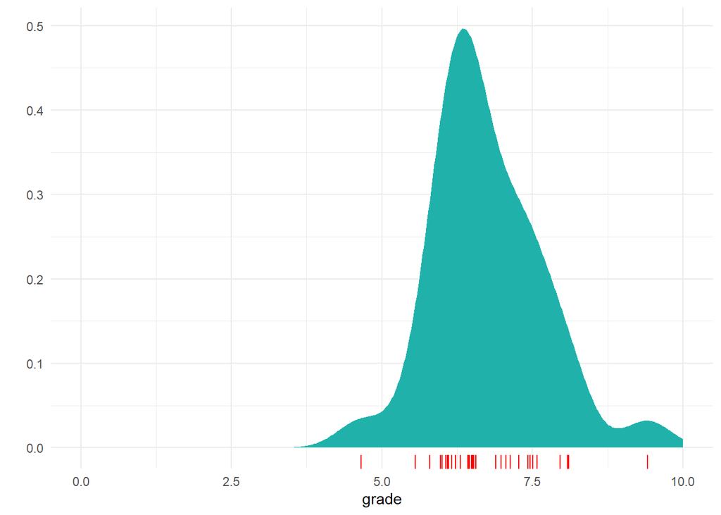

```r
gg_hist <- ggplot(data = gg_students, mapping = aes(x = grade)) +
  #geom_histogram(binwidth = 0.5, fill="Blue", colour="White", alpha=0.5) +
  geom_density(fill = "light seagreen", colour = NA) +
  geom_rug(colour = "Red", size = 0.5) +
  xlim(0, 10) +
  labs(y = "") +
  theme_minimal()
gg_hist
```

## Question 10:

**Create a boxplot of student grades per programme in the gg_students dataset you made earlier: map the programme variable to the x position and the grade to the y position. For extra visual aid, you can additionally map the programme variable to the fill aesthetic.**

## Question 11:

**What do each of the horizontal lines in the boxplot mean? What do the vertical lines (whiskers) mean?**

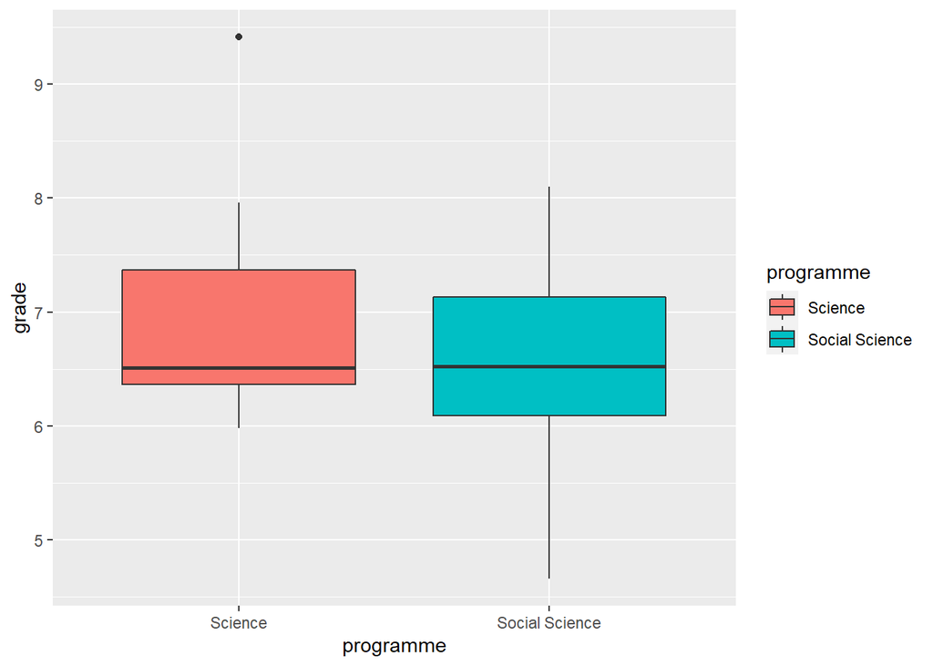

```r
gg_box <- ggplot(data = gg_students, ) +
  geom_boxplot(mapping = aes(x = programme, y = grade, fill = programme))
gg_box
```

vertical lines (whiskers) denote the lowest/highest values at most 1.5 IQR from the hinge

thick horizontal line denotes the median

thin horizontal lines at the edge of the box (hinges) denote the 25th and 75th percentiles

## Question 12:

**Comparison of distributions across categories can also be done by adding a fill aesthetic to the density plot you made earlier. Try this out. To take care of the overlap, you might want to add some transparency in the geom_density() function using the alpha argument.**

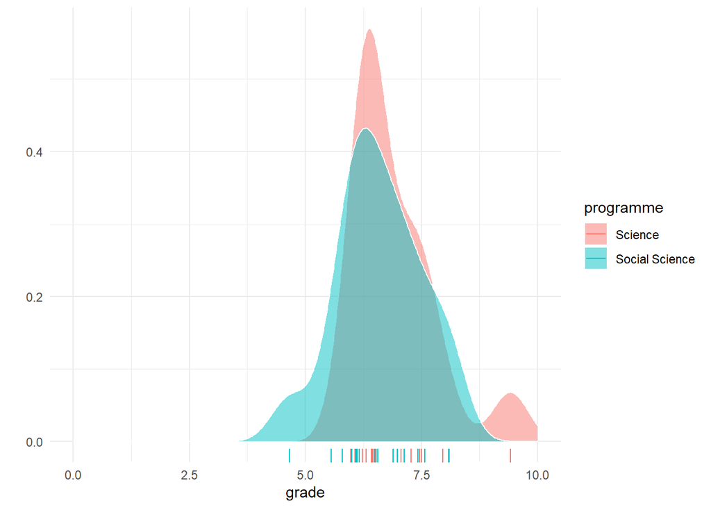

```r
gg_hist <- ggplot(data = gg_students, mapping = aes(x = grade)) +
  #geom_histogram(binwidth = 0.5, fill="Blue", colour="White", alpha=0.5) +
  geom_density(aes(fill = programme), colour = "White", alpha = 0.5) +
  geom_rug(aes(colour = programme), size = 0.5) +
  xlim(0, 10) +
  labs(y = "") +
  theme_minimal()
gg_hist
```